# Reading Comprehension

```r
#Play the above chunk and this one in your Console to access the data
View(Baumann)
?Baumann
```

### Background

“This study investigated the effectiveness of explicit instruction in ‘think aloud’ as a means to promote elementary students’ comprehension monitoring abilities” [(Baumann & Jones, 1992)](http://jlr.sagepub.com/content/24/2/143.full.pdf).

Details of the Study (click to view)

To summarize, 66 students were divided randomly into 3 experimental groups of equal size: the **Basal**, **DRTA**, and **Strat** groups. Each group of students received instruction by a different experimental method, and was then tested on their comprehension monitoring abilities. We wish to analyze the data to see **which of the three instructional methods, if any, were effective.**

The background study explains that two pretests were administered to discover whether students’ abilities varied by group *before instruction*. If at least one group’s ability is stochastically different, we should then analyze instructional method effectiveness based on *the difference* between pre- and post-test scores. If no significant differences can be found between groups in the pretests, we may assume all student’s had roughly equal ability prior to the treatment. This means we will be able to analyze instructional effectiveness based on the raw post-test data.

We will use the Kruskal-Wallis Rank Sum Test for all determinations. The hypotheses for each test in this analysis will be of the underlying form:

$$H_0: \text{The test scores are all from the same distribution.}$$
$$H_a: \text{At least one group's distribution is stochastically different for this test.}$$

### Analysis

When tested at the 5% significance level, Kruskal-Wallis tests for pretest 1 and 2 both indicate a p-value greater than 0.05.

```
    Kruskal-Wallis rank sum test

data:  pretest.1 by group
Kruskal-Wallis chi-squared = 2.2213, df = 2, p-value = 0.3294
```

```
    Kruskal-Wallis rank sum test

data:  pretest.2 by group
Kruskal-Wallis chi-squared = 0.19182, df = 2, p-value = 0.9085
```

Therefore, we will assume student comprehension ability was evenly distributed across all groups *prior to instruction*. Since we do not need to account for greater or lesser ability from one group or another, we may continue our analysis using the post-test scores alone.

Kruskal-Wallis tests were performed on the three post-tests to see if one group outperformed another. To balance our alpha values, each test is performed at the 1.667% significance level.

```
    Kruskal-Wallis rank sum test

data:  post.test.1 by group
Kruskal-Wallis chi-squared = 9.5952, df = 2, p-value = 0.008249
```

```
    Kruskal-Wallis rank sum test

data:  post.test.2 by group
Kruskal-Wallis chi-squared = 14.696, df = 2, p-value = 0.0006438
```

```
    Kruskal-Wallis rank sum test

data:  post.test.3 by group
Kruskal-Wallis chi-squared = 9.6319, df = 2, p-value = 0.0081
```

The p-values from all three tests are below the threshold, therefore we reject the null hypothesis in each case. We conclude that at least one group’s test score’s are stochastically different than the others for each post-test.

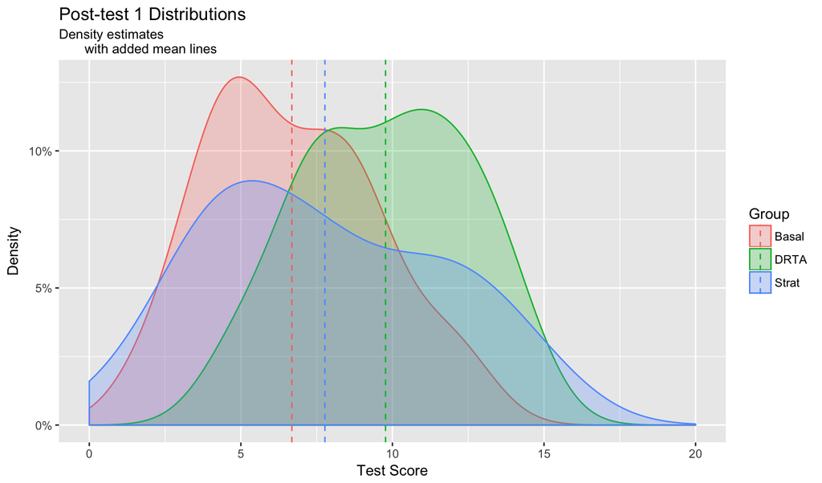

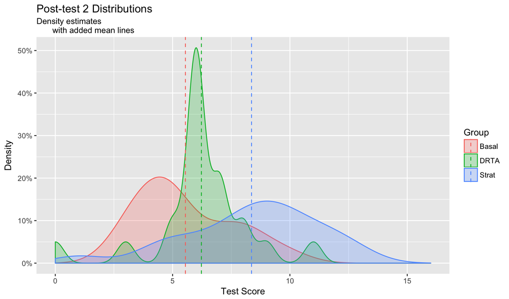

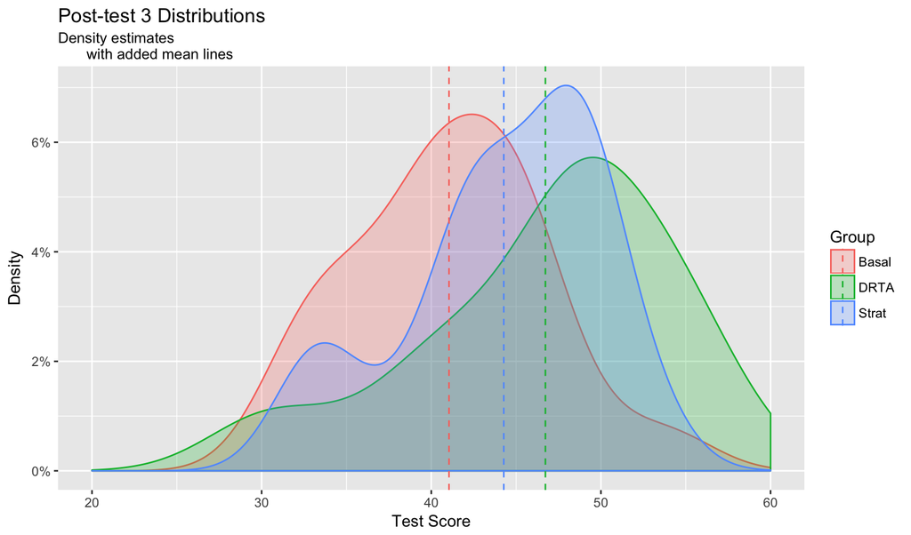

### Conclusion

The Kruskal-Wallis tests allow us to confirm with a great deal of certainty that the instructional methods employed by the teachers have a significant effect on student’s comprehension monitoring abilities. With the help of the density plots, we see where these groups defer in their ability:

- The DTRA group outperformed the other two in post-test 1, with the Strat group marginally outperforming the Basal group.
- The Strat group outperformed all others in post-test 2, with the DRTA group scoring better than the Basal group.
- The DRTA group performed best in post-test 3, and again the Basal group scored the lowest on average.

The effectiveness of the instructional method employed may depend on the tasks students are asked to perform. There is good evidence to suggest that the Strat approach helps students best when the tasks are like those asked of students in post-test 2. Overall, in all three tests the Strat and DRTA groups scored higher than the Basal group. At the very least, we may conclude these two instructional methods have a greater impact on student’s than that of the Basal method.